# carlydavenport_A4

Carly Davenport

10/12/2021

## Assignment 4

## Part 1 (6 points) equity analysis of educational attainment by race for Alameda county

The table I used was C15002 - SEX BY EDUCATIONAL ATTAINMENT FOR THE POPULATION 25 YEARS AND OVER

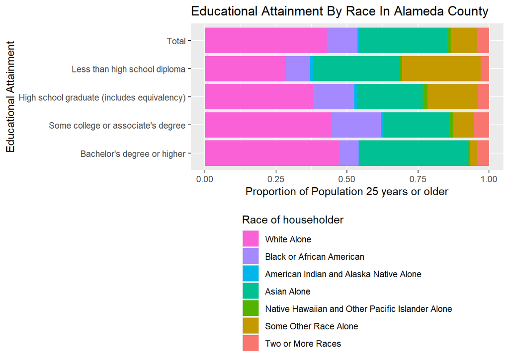

Reflection: comment on the observed under- or over-representation of different subpopulations. Essentially, respond to the question: “Is there disproportionate education attainment by race in the county?” Note that the universe of the ACS datasets on educational attainment is “population 25 years or older”, so be sure to clarify that in your visuals and commentary.

ANSWER: Based on the graph, there definitely seems to be disproportionate education attainment by race in Alameda county. Notably, respondents who were White Alone or Asian made up the highest proportions of respondents with a bachelor’s degree or higher. I noticed that the proportion of Asians with a bachelor’s degree or higher was greater than their proportion of the total population, and for White Alone it was slightly more than their population proportion, whereas for Black or African American, they make up a larger proportion of those with high school graduate or some college/associate’s degree than their proportion of the total population. I think this shows a clear distinction in how Black people have disproportionately lower levels of educational attainment. I noticed a similar trend for Some Other Race Alone, where despite making up only about 10% of the population, they make up about slightly less than 30% of those with less than a highschool diploma, which leaves me curious as to the racial and ethnic background of those in this group, although from prior knowledge I would presume many of these respondents are probably Hispanic. However, it is important to note these numbers apply for those 25 years and older, so I would be interested to figure out how numbers might stay the same or slightly change if those under 25 were also included, although I don’t think proportionally they would change by much.

## Part 2 (6.5 points) equity analysis of educational attainment by race for Alameda county

For 6.5 points, alter the previous analysis to be about educational attainment by ethnicity, where your three categories for ethnicity should be “Latinx”, “White, not Latinx”, and “Not White, not Latinx”.

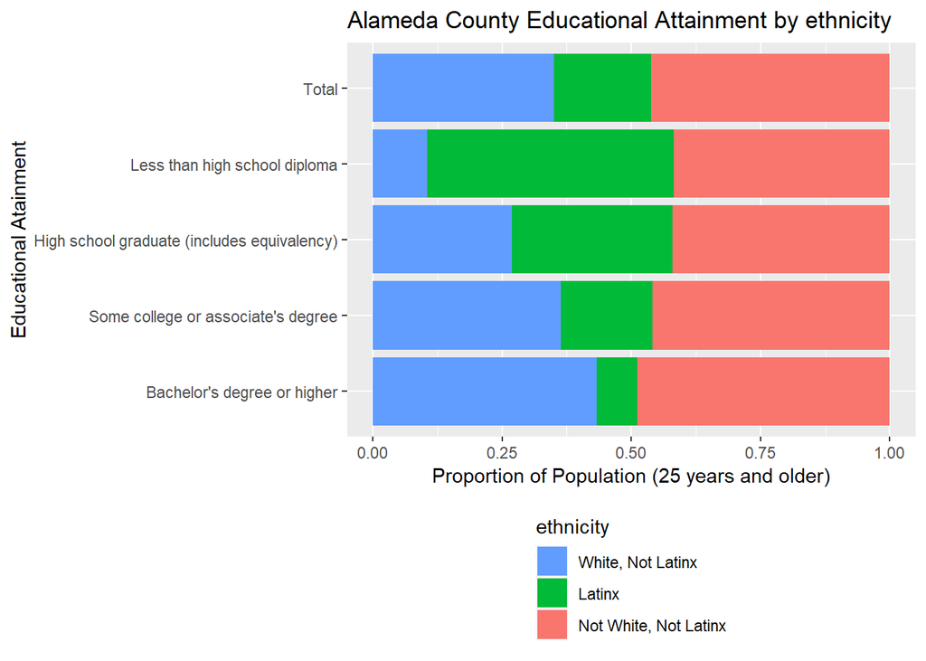

Reflection:

Looking at the results, there seems to be disproportionate educational attainment by ethnicity between White, not Latinx and Latinx categories. It also seems like if you compare this graph to the previous one, some of those who identify as white also must identify as latinx, since the total amount of White, Not Latinx, is less than the total proportion in the first graph. We see though that a largely disproportionate amount of those who identify as latinx make up those with less than a highschool diploma or a highschool diploma, and a greater proportion of white residents make up those with a bachelor’s degree or higher. Those who identify as “not white, not latinx” seem to maintain similar proportions to the proportion of the population they make up.